# Reproducible Research: Peer Assessment 1

## Loading and preprocessing the data

Assuming the activity.zip file is already in the working directory.

1. First we load the data from the activity.zip file

```r
unzip(zipfile="activity.zip")
activity_raw <- read.csv("activity.csv",stringsAsFactors=FALSE)
```

2.Secondly we format the data for analysis

```r
# Transform the date attribute to an actual date format
activity_raw$date <- as.POSIXct(activity_raw$date, format="%Y-%m-%d")

#Assign the formate data for analysis
data<-activity_raw
```

## What is mean total number of steps taken per day?

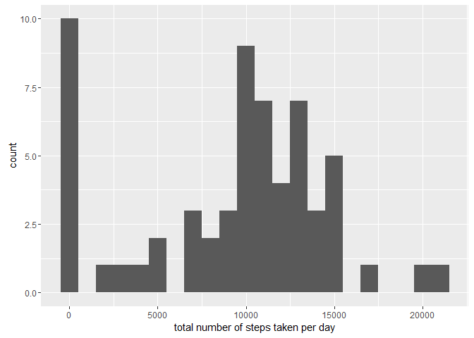

```r
library(ggplot2)
total.steps <- tapply(data$steps, data$date, FUN=sum, na.rm=TRUE)
qplot(total.steps, binwidth=1000, xlab="total number of steps taken per day")
```

The mean and median are computed as follows:

```r
mean_value = mean(total.steps, na.rm=TRUE)
median_value = median(total.steps, na.rm=TRUE)
```

The mean number of steps taken per day is: 9354.2295082

The median number of steps taken per day is: 10395

## What is the average daily activity pattern?

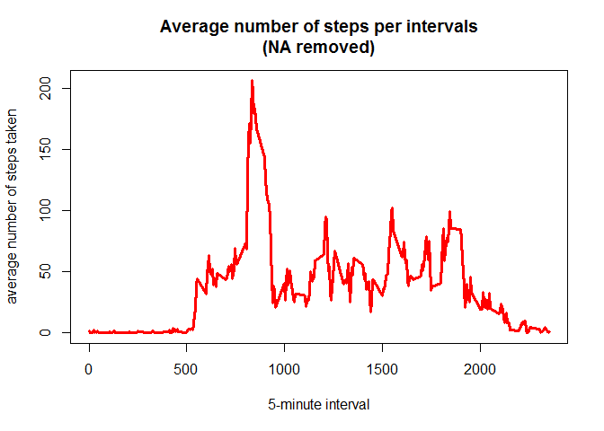

```r
averages <- aggregate(data$steps, by=list(data$interval),FUN=mean, na.rm=TRUE)
names(averages)<-c("interval","mean")

plot(averages$interval, averages$mean, type='l',
     col="red",
     lwd=3,
     xlab="5-minute interval",
     ylab="average number of steps taken",
     main="Average number of steps per intervals\n(NA removed)")
```

On average across all the days in the dataset, which 5-minute interval contains the maximum number of steps?

```r
max_pos <- which(averages$mean == max(averages$mean))
max_interval <- averages[max_pos, 1]
```

The 5-minute interval with the highest average value is: 835

## Imputing missing values

1. Calculate and report the total number of missing values in the dataset (i.e. the total number of rows with NAs)

```r
missing_rows <- sum(is.na(data$steps))
```

The number of rows with missing date is 2304

2.Strategy to filling in all of the missing values in the dataset with the mean for that 5-minute interval, etc.

3.Replace each missing value with the mean value of its 5-minute interval across all dates.

```r
fill_value <- function(steps, interval) {
    filled <- NA

    if (!is.na(steps)) {
        filled <- c(steps)
    }else{
        filled <- (averages[averages$interval==interval, "mean"])
    }
    return(filled)
}
filled_data <- data
filled_data$steps <- mapply(fill_value, filled_data$steps, filled_data$interval)
```

Histogram of the total number of steps taken each day and calculate the mean and median total number of steps.

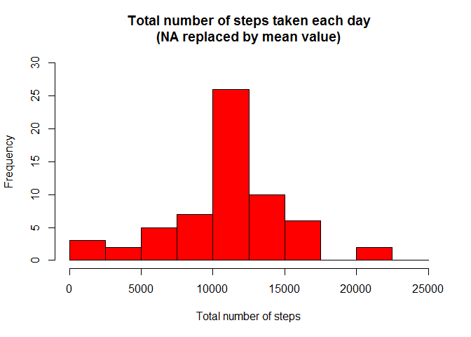

```r
total_steps <- aggregate(filled_data$steps, by=list(filled_data$date), FUN=sum)

names(total_steps) <- c("date", "total")

hist(total_steps$total,
     breaks=seq(from=0, to=25000, by=2500),
     col="red",
     xlab="Total number of steps",
     ylim=c(0, 30),
     main="Total number of steps taken each day\n(NA replaced by mean value)")
```

```r
mean(total_steps$total)
median(total_steps$total)
```

[output not shown]

## Are there differences in activity patterns between weekdays and weekends?

Find the day of the week for each measurement in the dataset.

```r
weekday_or_weekend <- function(date) {
    day <- weekdays(date)
    if (day %in% c("Monday", "Tuesday", "Wednesday", "Thursday", "Friday"))
        return("weekday")
    else if (day %in% c("Saturday", "Sunday"))
        return("weekend")
    else
        stop("invalid date")
}
filled_data$date <- as.Date(filled_data$date)
filled_data$day <- sapply(filled_data$date, FUN=weekday_or_weekend)
```

Panel plot containing plots of average number of steps taken on weekdays and weekends.

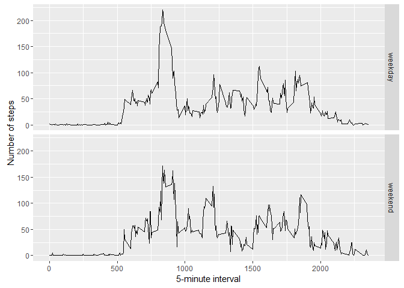

```r
averages <- aggregate(steps ~ interval + day, data=filled_data, mean)
ggplot(averages, aes(interval, steps)) + geom_line() + facet_grid(day ~ .) +
    xlab("5-minute interval") + ylab("Number of steps")
```